# Session 7: Visualizing Data

R Workshop for DBA Students

Author

Taikgun Song

Published

November 14, 2026

**Session Objectives**

By the end of this session, you will be able to:

1. Make quick exploratory plots with base R: `hist()`, `plot()`, `boxplot()`, and `barplot()`
2. Explain the grammar of graphics behind `ggplot2`: data, aesthetics, and geoms, built in layers
3. Make histograms, scatter plots, and side-by-side boxplots with `ggplot2`
4. Zoom in on a plot without silently dropping data
5. Use color and `facet_wrap()` to compare groups
6. Polish a figure for publication and save it with `ggsave()`

```r
library(tidyverse)
```

We continue with the finance data. This chunk rebuilds the working data from Sessions 5 and 6, adds the super sectors from Session 6, and drops the 7 firms with no net margin so the plots do not warn about them:

```r
finance_raw <- read.csv("data/finance_example.csv", check.names = FALSE)
names(finance_raw)[1] <- "ticker"

fin_plot <- as_tibble(finance_raw) |>
  select(ticker,
         sector            = Sector,
         revenue           = Revenue,
         net_margin        = `Net Profit Margin`,
         market_cap        = `Market Cap`,
         price_change_2015 = `2015 PRICE VAR [%]`) |>
  filter(revenue > 0, !is.na(net_margin)) |>
  mutate(super_sector = case_when(
    sector %in% c("Basic Materials", "Consumer Cyclical",
                  "Financial Services", "Real Estate")           ~ "Cyclical",
    sector %in% c("Consumer Defensive", "Healthcare", "Utilities") ~ "Defensive",
    sector %in% c("Communication Services", "Energy",
                  "Industrials", "Technology")                     ~ "Sensitive"))
```

# 1 Why Plot?

In Session 5, `summary()` and `group_by()` told us a lot about this data. But a table of medians would never have shown us a company worth $96 trillion, or that a few firms have net margins of minus 300,000%. A plot shows every observation at once, so problems and patterns that summaries hide become obvious.

**Plot before you model.** Every analysis in your statistics course should start with a few plots of the variables involved.

# 2 Quick Looks with Base R

Base R’s plotting functions are built in and need one line each. They are ideal for a quick look while you explore.

## 2.1 `hist()`: One Numeric Variable

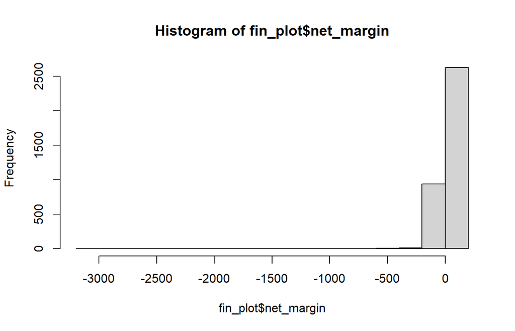

```r
hist(fin_plot$net_margin)
```

One tall bar and nothing else? A handful of extreme values stretch the x-axis so far that almost every firm lands in a single bar. Look at the middle of the distribution instead, and say so in the title:

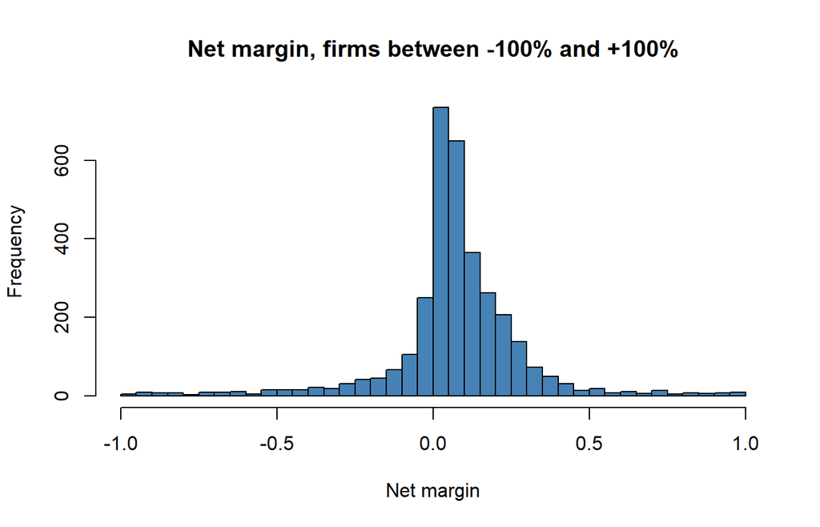

```r
middle <- fin_plot$net_margin[fin_plot$net_margin > -1 & fin_plot$net_margin < 1]

hist(middle,
     breaks = 50,                                   # number of bars (approximately)
     main   = "Net margin, firms between -100% and +100%",
     xlab   = "Net margin",
     col    = "steelblue")
```

## 2.2 `plot()`: Two Numeric Variables

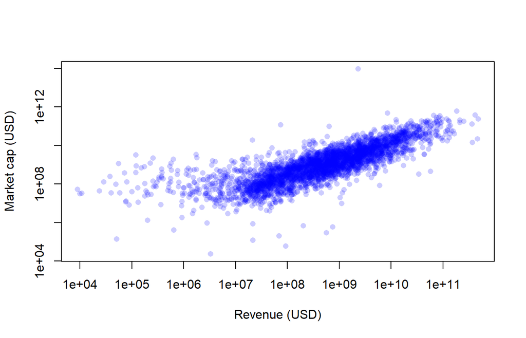

```r
big_enough <- fin_plot$market_cap > 0 & !is.na(fin_plot$market_cap)   # log needs > 0

plot(fin_plot$revenue[big_enough], fin_plot$market_cap[big_enough],
     log  = "xy",                                   # log scale on both axes
     xlab = "Revenue (USD)",
     ylab = "Market cap (USD)",
     pch  = 16,                                     # solid dots
     col  = rgb(0, 0, 1, alpha = 0.2))              # transparent blue
```

Revenue and market cap span from thousands to trillions of dollars. On ordinary axes, all but a few firms would be squeezed into one corner. A **log scale** spreads them out: each step on the axis is ten times the previous one.

## 2.3 `boxplot()`: Side by Side, with Variable Width

A boxplot shows the median (thick line), the middle 50% of values (the box), and outlying points. With a formula, `boxplot()` draws one box per group. `varwidth = TRUE` makes each box’s width proportional to the square root of the group’s size, so you can see at a glance which groups are large and which are small:

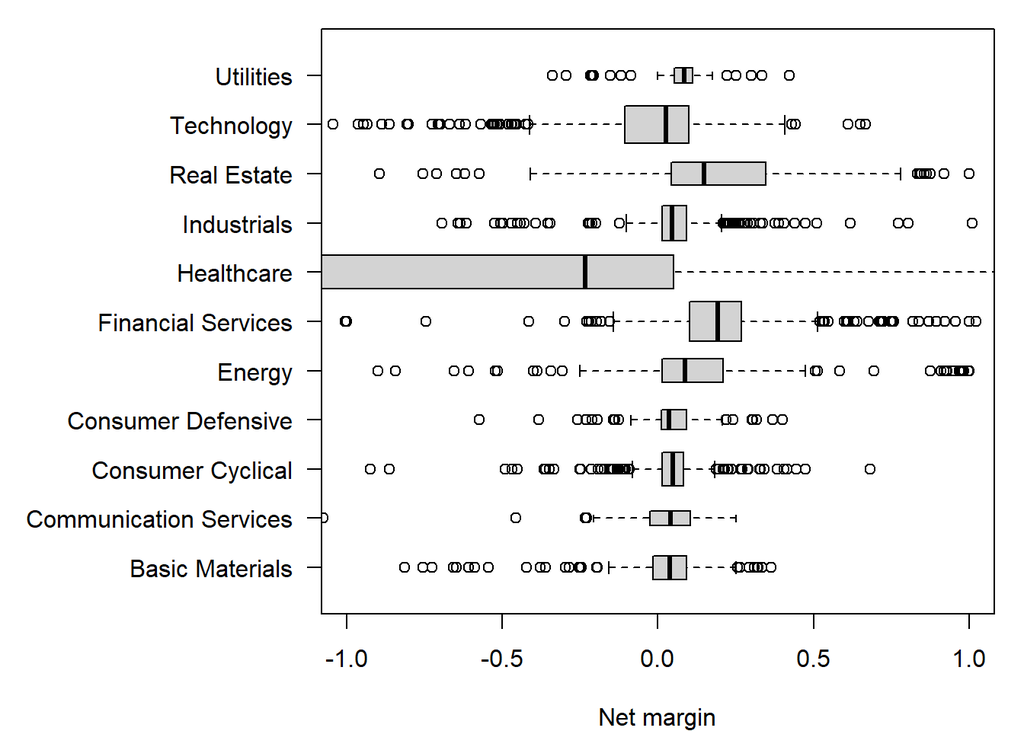

```r
par(mar = c(4, 11, 1, 1))                           # wider left margin for long names

boxplot(net_margin ~ sector, data = fin_plot,
        horizontal = TRUE,                          # long group names fit better
        las        = 1,                             # horizontal axis labels
        varwidth   = TRUE,                          # box width shows group size
        ylim       = c(-1, 1),                      # zoom in on the value axis
        xlab       = "Net margin",
        ylab       = "")
```

`ylim` here **zooms in**: the boxes are still computed from all the data, including the firms outside the visible range. (In a horizontal boxplot, `ylim` refers to the value axis.) We return to this distinction in Section 4.

## 2.4 `barplot()`: Counts

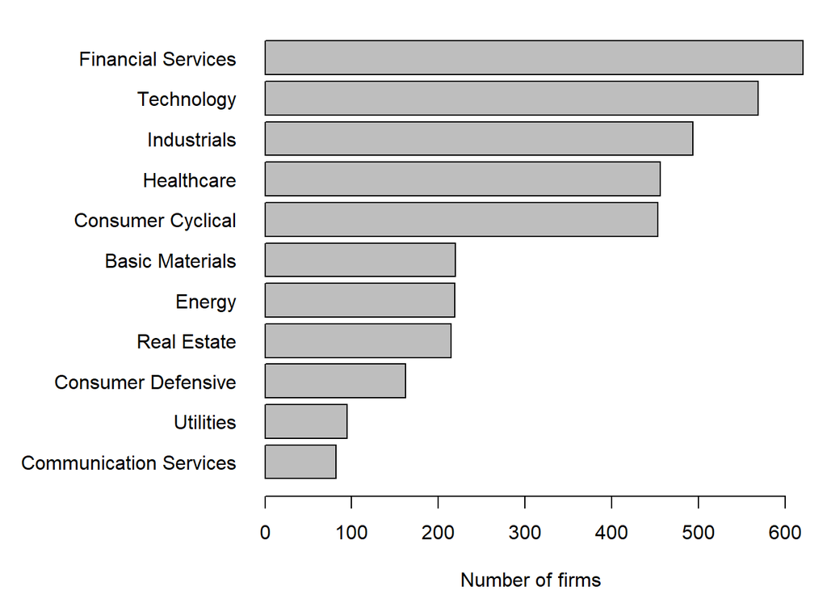

```r
par(mar = c(4, 11, 1, 1))

barplot(sort(table(fin_plot$sector)),
        horiz = TRUE, las = 1,
        xlab  = "Number of firms")
```

**Common base R arguments**

`main` (title), `xlab` and `ylab` (axis labels), `col` (color), `xlim` and `ylim` (axis ranges), `log = "x"`, `"y"`, or `"xy"` (log scales), `las = 1` (horizontal axis labels), and `par(mar = c(bottom, left, top, right))` for margins. In a Quarto document, `par()` settings apply to that chunk only; in a script, they stay until you change them back.

Base R plots are quick, but each one is built differently and polishing them takes a lot of small arguments. For figures you will refine and publish, `ggplot2` is the standard.

# 3 The Grammar of Graphics

`ggplot2` (part of the tidyverse) builds every plot from the same three pieces:

| Piece | What it is | Example |
| --- | --- | --- |
| **Data** | A data frame, ideally tidy (Session 6) | `fin_plot` |
| **Aesthetics**, `aes()` | Which column goes to which visual property: x, y, color, fill, size | `aes(x = revenue, y = market_cap)` |
| **Geoms**, `geom_*()` | The type of mark that represents the data: points, bars, boxes, lines | `geom_point()` |

You build a plot in **layers**, adding each piece with `+`:

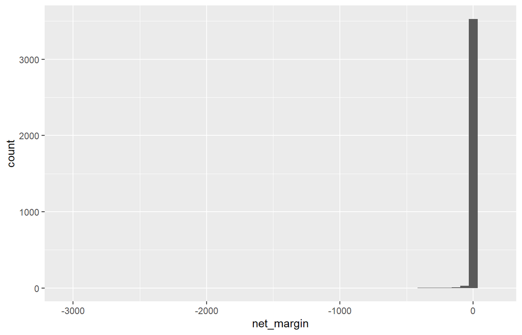

```r
ggplot(fin_plot, aes(x = net_margin)) +            # data and aesthetics: an empty canvas
  geom_histogram(bins = 50)                         # a layer of bars
```

The same extreme values flatten this histogram too. We fix that in Section 4.

**`+`, not `|>`**

`ggplot2` is older than the pipe, so its layers are joined with `+`. A pipe can lead **into** a plot, `fin_plot |> filter(...) |> ggplot(aes(...))`, but after `ggplot()` every step is `+`. Using `|>` between layers gives an error, and so does putting `+` at the **start** of a line instead of the end of the previous one.

## 3.1 What `ggplot2` Offers

There is a geom for almost every kind of chart. We use three in this session; the others work the same way:

| Chart | Geom |
| --- | --- |
| Histogram | `geom_histogram()` |
| Density curve | `geom_density()` |
| Scatter plot | `geom_point()` |
| Trend line | `geom_smooth()` |
| Boxplot | `geom_boxplot()` |
| Violin plot | `geom_violin()` |
| Bar chart of counts | `geom_bar()` |
| Bar chart of values you computed | `geom_col()` |
| Line chart (e.g. over time) | `geom_line()` |
| Heatmap | `geom_tile()` |
| Text labels | `geom_text()` |

The [ggplot2 reference](https://ggplot2.tidyverse.org/reference/) and the Posit cheatsheet list them all with examples.

# 4 Zooming without Dropping Data

To focus on the middle of the distribution, there are two very different approaches.

**For a histogram**, filter explicitly and say so. Then the bars are recalculated for the values you show:

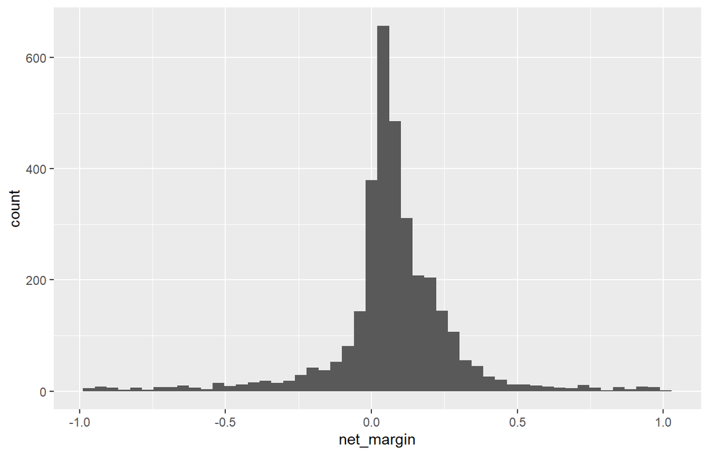

```r
fin_plot |>
  filter(net_margin > -1, net_margin < 1) |>
  ggplot(aes(x = net_margin)) +
  geom_histogram(bins = 50)
```

**For boxplots and trend lines, be careful.** Here are side-by-side boxplots of net margin by sector, zoomed in two ways. `coord_cartesian()` **zooms**, like a camera, and every box is still computed from all the firms:

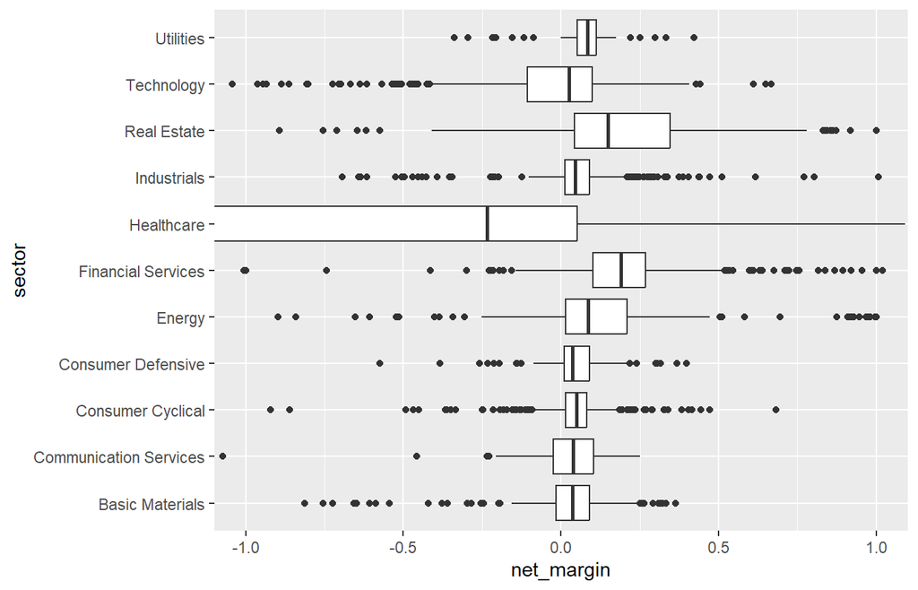

```r
ggplot(fin_plot, aes(x = net_margin, y = sector)) +
  geom_boxplot() +
  coord_cartesian(xlim = c(-1, 1))
```

Setting the axis limits with `scale_x_continuous(limits = ...)` looks like the same thing, but it **removes** every observation outside the limits **before** computing the boxes:

```
Warning: Removed 282 rows containing non-finite values (`stat_boxplot()`).
```

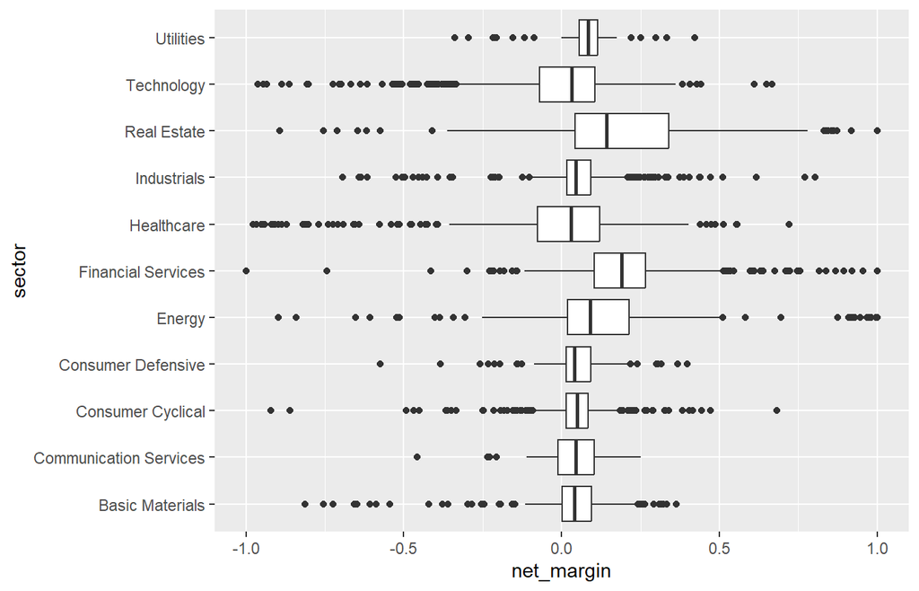

```r
ggplot(fin_plot, aes(x = net_margin, y = sector)) +
  geom_boxplot() +
  scale_x_continuous(limits = c(-1, 1))
```

Read the warning: R removed 282 firms. Now compare the Healthcare box in the two plots. Its median moved from a loss to a profit. The numbers confirm it:

```r
fin_plot |>
  filter(sector == "Healthcare") |>
  summarise(median_all_firms     = median(net_margin),
            median_within_limits = median(net_margin[net_margin >= -1 & net_margin <= 1]))
```

```
# A tibble: 1 × 2
  median_all_firms median_within_limits
             <dbl>                <dbl>
1           -0.234               0.0298
```

**Zoom with `coord_cartesian()`**

Use `coord_cartesian(xlim = , ylim = )` to zoom in. Scale limits (`xlim()`, `ylim()`, `scale_*(limits = )`) silently drop data and change every statistic the plot computes: boxes, medians, and trend lines. If you do want to exclude observations, filter them explicitly and report it.

# 5 Scatter Plots

## 5.1 Points and Log Scales

A scatter plot shows the relationship between two numeric variables. Market cap must be positive for a log scale, so we filter first:

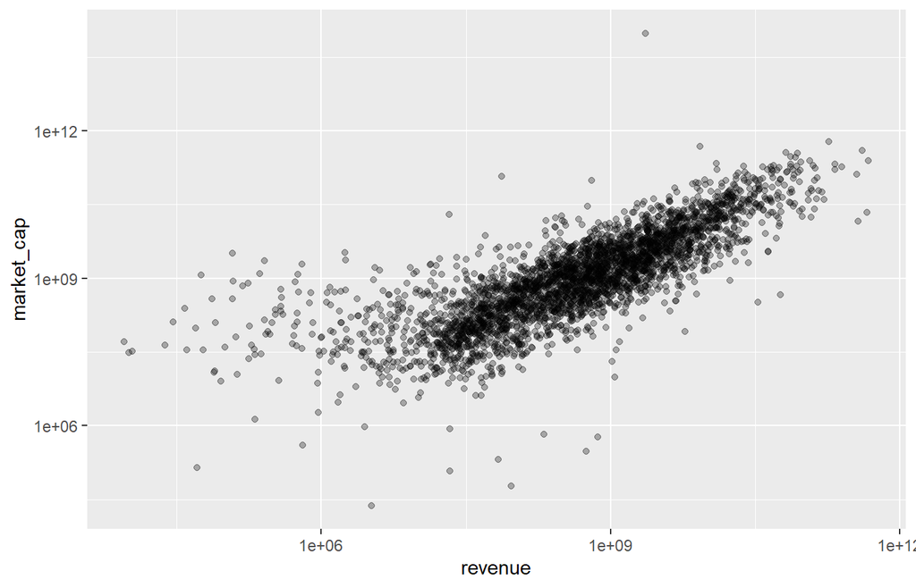

```r
fin_scatter <- fin_plot |> filter(market_cap > 0)

ggplot(fin_scatter, aes(x = revenue, y = market_cap)) +
  geom_point(alpha = 0.3) +                         # transparency shows overlapping points
  scale_x_log10() +
  scale_y_log10()
```

With 3,000+ firms, many points overlap; `alpha` (from 0, invisible, to 1, solid) lets dense regions show up darker. Notice the lone point at the very top: the $96 trillion firm from Session 5.

## 5.2 Adding a Trend Line

`geom_smooth()` adds a fitted line. `method = "lm"` fits a straight line (a linear regression, on the log scales shown):

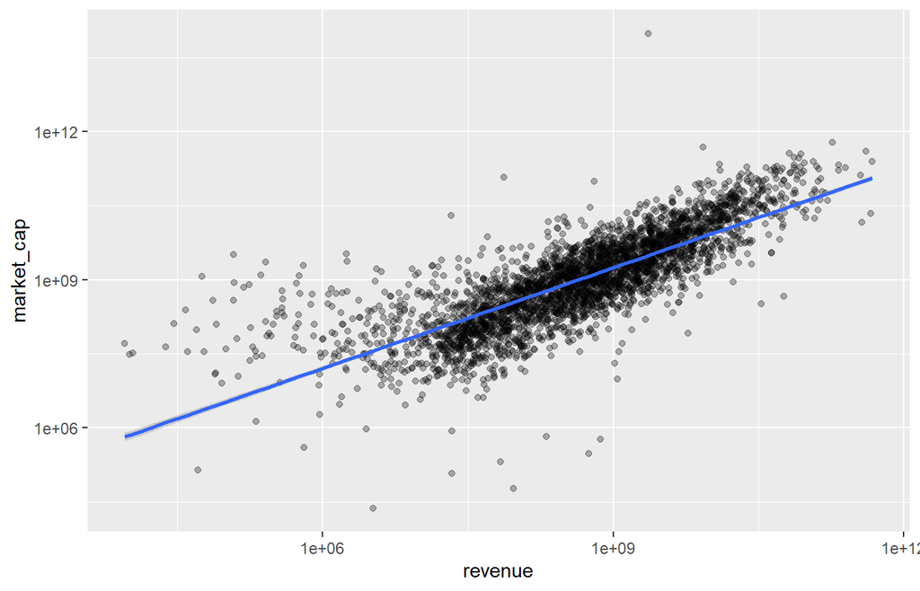

```r
ggplot(fin_scatter, aes(x = revenue, y = market_cap)) +
  geom_point(alpha = 0.3) +
  geom_smooth(method = "lm", formula = y ~ x) +
  scale_x_log10() +
  scale_y_log10()
```

The grey band is a confidence interval for the line. Your statistics course will explain what the line and band mean; here it is a visual summary of the relationship.

## 5.3 Mapping vs. Setting Color

There are two ways to use color, and mixing them up is the most common `ggplot2` mistake:

- **Mapping** a column to color, **inside** `aes()`: color shows the data, and a legend appears
- **Setting** one color for everything, **outside** `aes()`

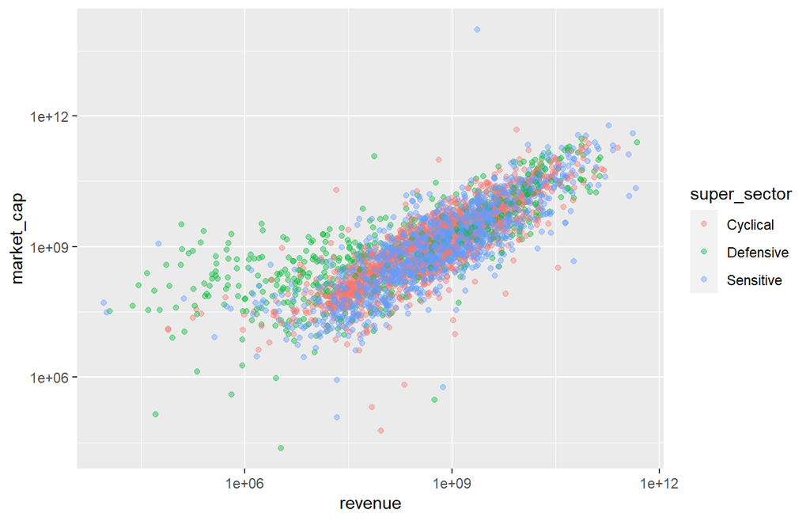

```r
ggplot(fin_scatter, aes(x = revenue, y = market_cap, color = super_sector)) +   # mapped
  geom_point(alpha = 0.4) +
  scale_x_log10() +
  scale_y_log10()
```

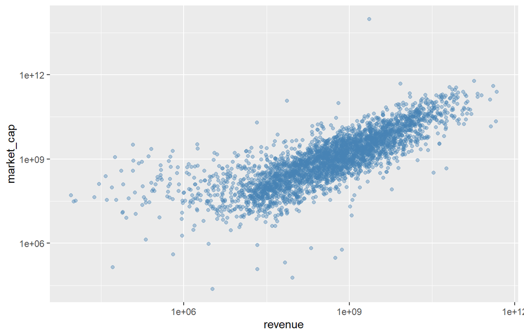

```r
ggplot(fin_scatter, aes(x = revenue, y = market_cap)) +
  geom_point(alpha = 0.4, color = "steelblue") +                                # set
  scale_x_log10() +
  scale_y_log10()
```

Try `aes(color = "steelblue")`: ggplot treats `"steelblue"` as a column of data with one value, colors every point the default red, and adds a legend titled “steelblue”.

`color` is for points and lines; `fill` is for the inside of bars and boxes.

# 6 Side-by-Side Boxplots

Boxplots compare a numeric variable across groups. Three improvements make them much easier to read:

1. **Order the groups** by their median with `fct_reorder()` (forcats), so the plot reads from lowest to highest
2. **Put long names on the y-axis**, so they are horizontal and readable
3. **Show group size** with `varwidth = TRUE`: wider boxes mean more firms

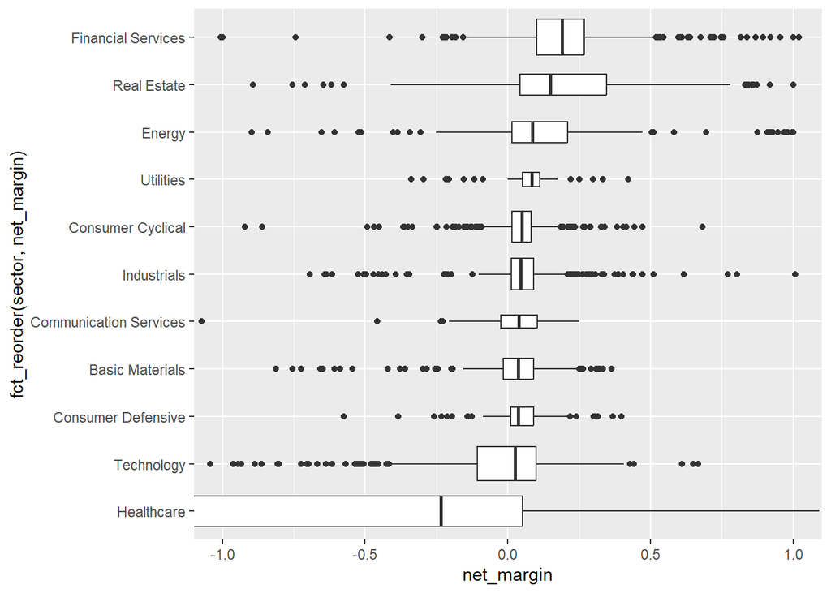

```r
ggplot(fin_plot, aes(x = net_margin,
                     y = fct_reorder(sector, net_margin))) +   # order sectors by median
  geom_boxplot(varwidth = TRUE) +                               # width shows group size
  coord_cartesian(xlim = c(-1, 1))                              # zoom, do not drop
```

Financial Services, the widest box, is the largest sector; Communication Services, the narrowest, is the smallest. The ordering shows Healthcare with the lowest median margin and Financial Services with the highest.

**Base R and ggplot2, side by side**

The same plot in base R is `boxplot(net_margin ~ sector, data = fin_plot, horizontal = TRUE, varwidth = TRUE, ylim = c(-1, 1))` (Section 2.3). Both zoom without dropping data.

# 7 Small Multiples with `facet_wrap()`

Instead of putting every group in one crowded plot, `facet_wrap()` draws one small panel per group, with the same axes so the panels are easy to compare:

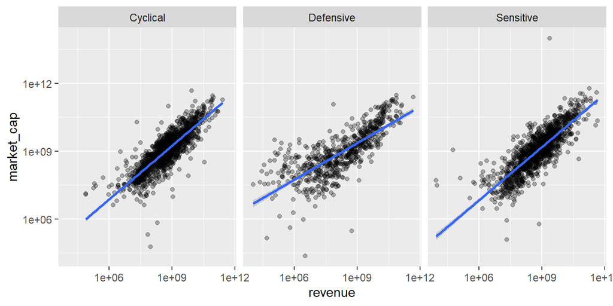

```r
ggplot(fin_scatter, aes(x = revenue, y = market_cap)) +
  geom_point(alpha = 0.3) +
  geom_smooth(method = "lm", formula = y ~ x) +
  scale_x_log10() +
  scale_y_log10() +
  facet_wrap(~ super_sector)
```

`facet_wrap(~ sector)` would give 11 panels, arranged in a grid; `ncol` and `nrow` control the layout.

# 8 Publication-Ready Figures

## 8.1 Labels, Scales, Themes, and Colors

The plots so far are fine for exploring. For a paper or a presentation, add:

- **`labs()`** for a title, axis labels, legend title, and a caption with the data source
- **Readable axis numbers** with the `scales` package (installed with ggplot2): `$1B` instead of `1e+09`, `20%` instead of `0.2`
- **A clean theme**, such as `theme_minimal()` or `theme_bw()`
- **Colorblind-friendly colors**: the viridis palettes are built into ggplot2

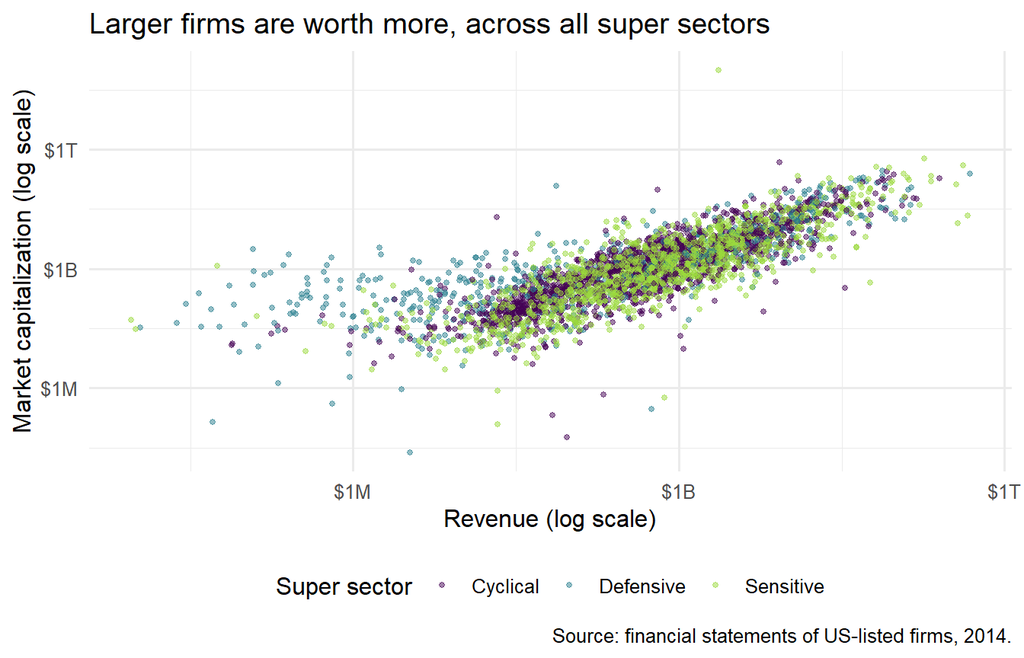

```r
p_final <- ggplot(fin_scatter, aes(x = revenue, y = market_cap, color = super_sector)) +
  geom_point(alpha = 0.5, size = 1) +
  scale_x_log10(labels = scales::label_dollar(scale_cut = scales::cut_short_scale())) +
  scale_y_log10(labels = scales::label_dollar(scale_cut = scales::cut_short_scale())) +
  scale_color_viridis_d(end = 0.85) +                  # colorblind-friendly
  labs(title    = "Larger firms are worth more, across all super sectors",
       x        = "Revenue (log scale)",
       y        = "Market capitalization (log scale)",
       color    = "Super sector",
       caption  = "Source: financial statements of US-listed firms, 2014.") +
  theme_minimal(base_size = 12) +
  theme(legend.position = "bottom")

p_final
```

Saving the plot as an object (`p_final`) lets you display it, change it (`p_final + theme_bw()`), or save it to a file.

**A title that states the finding**

“Revenue vs. market cap” describes the axes. “Larger firms are worth more, across all super sectors” tells the reader what to see. For presentations, the second kind works much better.

## 8.2 Saving with `ggsave()`

`ggsave()` writes a plot to a file. Give the size in inches, the size it will appear at in the document, so the text in the figure has the right size:

```r
dir.create("output", showWarnings = FALSE)

ggsave("output/revenue_marketcap.png", p_final,
       width = 6.5, height = 4.5, dpi = 300)     # raster: Word, PowerPoint, the web

ggsave("output/revenue_marketcap.pdf", p_final,
       width = 6.5, height = 4.5)                # vector: sharp at any size, LaTeX
```

| Format | Type | Use it for |
| --- | --- | --- |
| PDF | Vector: sharp at any zoom | LaTeX papers; journals that accept vector figures |
| PNG | Raster: a grid of pixels | Word, PowerPoint, websites. Use `dpi = 300` or more for print |
| TIFF | Raster | Some journals require it: `ggsave("fig.tiff", dpi = 600, compression = "lzw")` |

Journals state their requirements (format, width, resolution) in their author guidelines. A single-column figure is typically around 3.5 inches wide and a full-page-width figure around 7 inches.

# 9 Your Turn

**Exercise**

Use `fin_plot` (and `fin_scatter`) from this session.

1. **Base R histogram.** Draw a histogram of `price_change_2015` for firms whose price changed by between -100% and +200%, with 40 bars, a title, and an x-axis label.
2. **Base R boxplots.** Draw side-by-side boxplots of `price_change_2015` by `super_sector`, with variable width, zoomed in to -100 to 100. Which super sector had the lowest median price change in 2015?
3. **ggplot2 boxplots.** Make the same comparison with `ggplot2`, by `sector` instead: horizontal boxes ordered by median, `varwidth = TRUE`, and zoomed with `coord_cartesian()`. Which sector stands out?
4. **Scatter plot.** Plot `price_change_2015` (y) against `net_margin` (x), with transparent points and a straight trend line. First try it with all firms, zoomed with `coord_cartesian(xlim = c(-1, 1), ylim = c(-100, 200))`. Where is the trend line? Then **filter** to firms with net margins between -1 and 1 and price changes between -100 and 200, plot again, and add `facet_wrap(~ super_sector)`. Did more profitable firms see larger price increases in 2015?
5. **Publish it.** Add a title that states your finding, axis labels with `scales::label_percent()` for net margin, a caption, and `theme_minimal()`. Save it as `output/margin_price.png` at 6.5 by 4 inches and 300 dpi.

```r
# 1. Base R histogram


# 2. Base R boxplots


# 3. ggplot2 boxplots


# 4. Scatter plot


# 5. Publish it
```

**Solution (click to expand)**

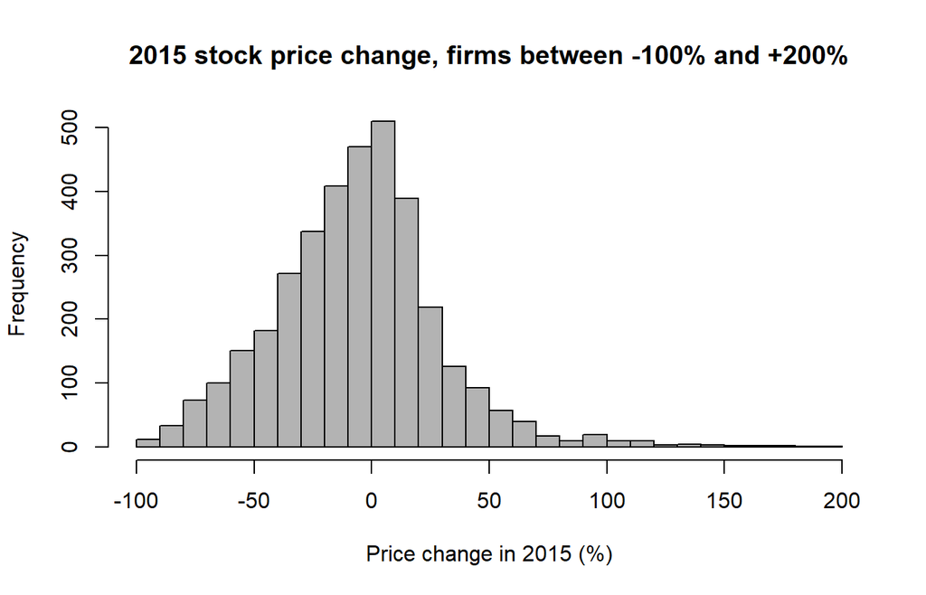

```r
# 1.
pc <- fin_plot$price_change_2015
hist(pc[pc > -100 & pc < 200], breaks = 40,
     main = "2015 stock price change, firms between -100% and +200%",
     xlab = "Price change in 2015 (%)", col = "grey70")
```

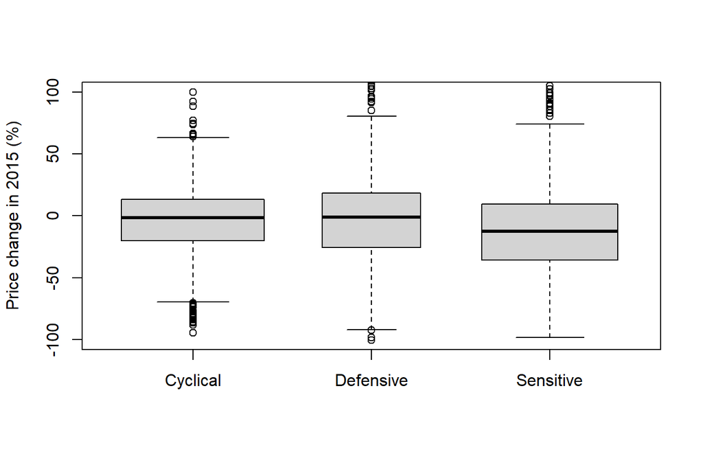

```r
# 2. The Sensitive super sector (which includes Energy) had the lowest median
boxplot(price_change_2015 ~ super_sector, data = fin_plot,
        varwidth = TRUE, ylim = c(-100, 100),
        xlab = "", ylab = "Price change in 2015 (%)")
```

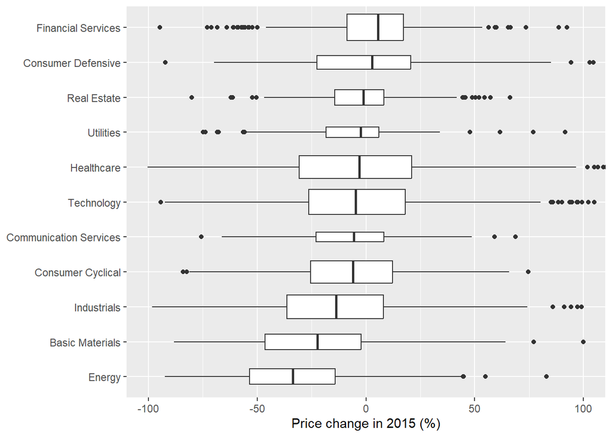

```r
# 3. Energy, far below every other sector (the 2014-2015 oil price collapse)
ggplot(fin_plot, aes(x = price_change_2015,
                     y = fct_reorder(sector, price_change_2015))) +
  geom_boxplot(varwidth = TRUE) +
  coord_cartesian(xlim = c(-100, 100)) +
  labs(x = "Price change in 2015 (%)", y = NULL)
```

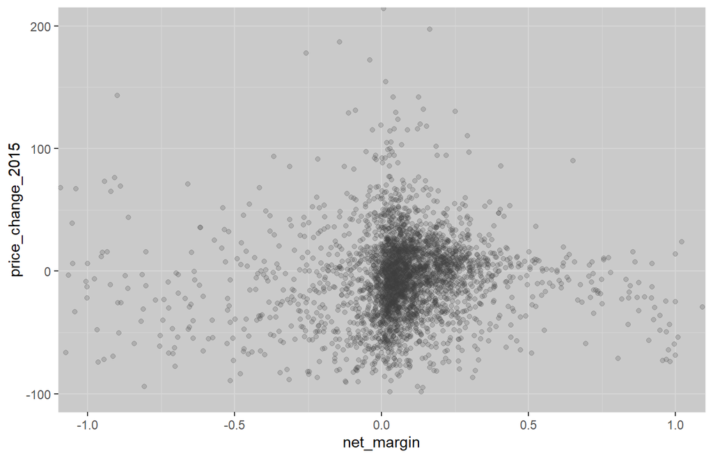

```r
# 4a. All firms, zoomed: the line is fitted to ALL firms, so a few extreme
#     price changes (one is over 2 million percent) pull it far above the plot
ggplot(fin_plot, aes(x = net_margin, y = price_change_2015)) +
  geom_point(alpha = 0.2) +
  geom_smooth(method = "lm", formula = y ~ x) +
  coord_cartesian(xlim = c(-1, 1), ylim = c(-100, 200))
```

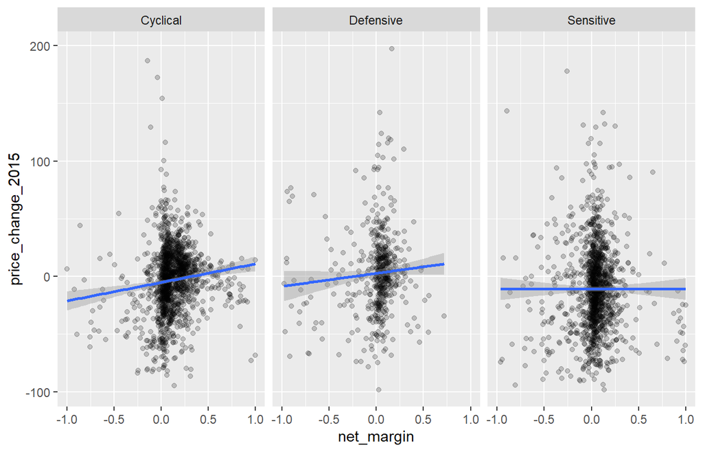

```r
# 4b. Typical firms only, filtered explicitly (and reported)
fin_typical <- fin_plot |>
  filter(between(net_margin, -1, 1), between(price_change_2015, -100, 200))

p_margin <- ggplot(fin_typical, aes(x = net_margin, y = price_change_2015)) +
  geom_point(alpha = 0.2) +
  geom_smooth(method = "lm", formula = y ~ x)

p_margin + facet_wrap(~ super_sector)
```

Among typical firms, the line slopes upward for Cyclical and Defensive firms: more profitable firms tended to do better in 2015. For Sensitive firms (which include Energy), it is nearly flat. Zooming keeps the outliers in every calculation, which is honest for boxplots but makes a straight trend line meaningless here; when outliers dominate a fitted line, filter explicitly and report how many firms you excluded (`nrow(fin_plot) - nrow(fin_typical)`).

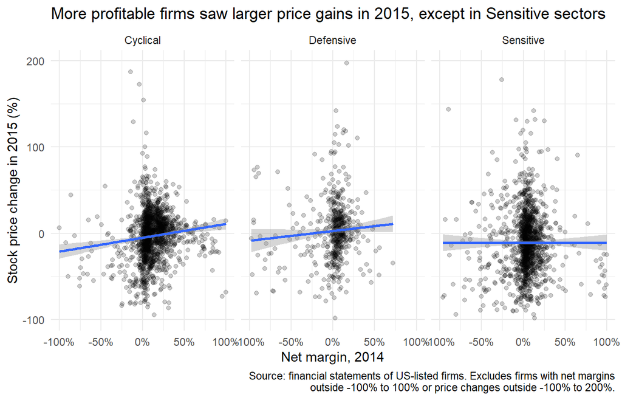

```r
# 5.
p_margin_final <- p_margin +
  facet_wrap(~ super_sector) +
  scale_x_continuous(labels = scales::label_percent()) +
  labs(title   = "More profitable firms saw larger price gains in 2015, except in Sensitive sectors",
       x       = "Net margin, 2014",
       y       = "Stock price change in 2015 (%)",
       caption = "Source: financial statements of US-listed firms. Excludes firms with net margins\noutside -100% to 100% or price changes outside -100% to 200%.") +
  theme_minimal()

p_margin_final
```

```r
ggsave("output/margin_price.png", p_margin_final, width = 6.5, height = 4, dpi = 300)
```

`scale_x_continuous(labels = ...)` changes only the **labels**, not the limits, so it drops no data. `between(x, a, b)` (from dplyr) is a shortcut for `x >= a & x <= b`.

# 10 Summary

- **Plot before you model:** plots show what summaries hide (Section 1).
- **Base R** (`hist()`, `plot()`, `boxplot()`, `barplot()`) is ideal for quick looks; `boxplot(varwidth = TRUE)` shows group sizes (Section 2).
- **`ggplot2`** builds plots from data, `aes()`, and geoms, in layers joined with `+` (Section 3).
- **Zoom with `coord_cartesian()`.** Scale limits silently drop data and change boxes and trend lines (Section 4).
- **Scatter plots:** log scales for skewed data, `alpha` for overlap, `geom_smooth()` for a trend. Color inside `aes()` maps data; outside, it sets a fixed color (Section 5).
- **Side-by-side boxplots:** order with `fct_reorder()`, names on the y-axis, `varwidth = TRUE` (Section 6).
- **`facet_wrap()`** draws one panel per group (Section 7).
- **For publication:** `labs()` with a title that states the finding, `scales` labels, a clean theme, viridis colors, and `ggsave()` at the final size (Section 8).

**Next session:** descriptive statistics, model syntax, and publication-ready tables.

## 10.1 Further Reading

- [R for Data Science (2e): Data visualization](https://r4ds.hadley.nz/data-visualize.html)
- [R for Data Science (2e): Communication](https://r4ds.hadley.nz/communication.html)
- [ggplot2 reference](https://ggplot2.tidyverse.org/reference/)
- [Posit cheatsheets](https://posit.co/resources/cheatsheets/): Data visualization with ggplot2